```r
options(scipen=999)

# Importing the libraries

library(tidyverse)
library(dplyr)
library(glue)
```

```r
library(ggplot2)
library(ggcorrplot)
library(broom)
library(funModeling) #to utilize plot_num
library(lubridate)
library(viridis)
library(GGally)
library(scales)
```

# Objective

Spotify is the worlds largest audio streaming application with services available in more than 175 countries. With a market share of approximately 32%, it has 365 million monthly active users, including 165 million paying subscribers, as of June 2021. A user can search for music based on a song, artist and genre album. They can create, share, edit playlists with other listeners all over the world. With such a massive user base, as one would imagine Spotify data is a gold mine for training machine learning algorithms and recommendation based systems. As a freemium service, Spotify implements multitudes of data learning tools and algorithms to leverage its data and create a streamlined experience for its users, unmatched by its competitors. Our objective with this project is to gain a deeper understanding of the Data Science discipline by accessing this data, and doing some preliminary analysis to come up with some conclusive observations.

## Organization of the Report

- Objective
- Methodology
  - Web Data Collection
  - Pre-processing
- Analysis and Visualizations
  - Popularity of each genre
  - Correlation Map
- Modeling the Data
- Potential Bias and Conclusion

# Methodology

In this section, the process of data gathering and cleaning are discussed.

## Web Data Collection

```r
#Importing the data set

tracks <- read_csv("https://raw.githubusercontent.com/sushmaakoju/spotify-tracks-data-analysis/main/SpotifyFeatures.csv")
head(tracks,n=10)
```

```
## # A tibble: 10 x 18
##    genre artist_name  track_name   track_id popularity acousticness danceability
##    <chr> <chr>        <chr>        <chr>         <dbl>        <dbl>        <dbl>
##  1 Movie Henri Salva~ C'est beau ~ 0BRjO6g~          0      0.611          0.389
##  2 Movie Martin & le~ Perdu d'ava~ 0BjC1Nf~          1      0.246          0.59
##  3 Movie Joseph Will~ Don't Let M~ 0CoSDzo~          3      0.952          0.663
##  4 Movie Henri Salva~ Dis-moi Mon~ 0Gc6TVm~          0      0.703          0.24
##  5 Movie Fabien Nataf Ouverture    0IuslXp~          4      0.95           0.331
##  6 Movie Henri Salva~ Le petit so~ 0Mf1jKa~          0      0.749          0.578
##  7 Movie Martin & le~ Premières r~ 0NUiKYR~          2      0.344          0.703
##  8 Movie Laura Mayne  Let Me Let ~ 0PbIF9Y~         15      0.939          0.416
##  9 Movie Chorus       Helka        0ST6uPf~          0      0.00104        0.734
## 10 Movie Le Club des~ Les bisous ~ 0VSqZ3K~         10      0.319          0.598
## # ... with 11 more variables: duration_ms <dbl>, energy <dbl>,
## #   instrumentalness <dbl>, key <chr>, liveness <dbl>, loudness <dbl>,
## #   mode <chr>, speechiness <dbl>, tempo <dbl>, time_signature <chr>,
## #   valence <dbl>
```

```r
colnames(tracks)
```

```
##  [1] "genre"            "artist_name"      "track_name"       "track_id"
##  [5] "popularity"       "acousticness"     "danceability"     "duration_ms"
##  [9] "energy"           "instrumentalness" "key"              "liveness"
## [13] "loudness"         "mode"             "speechiness"      "tempo"
## [17] "time_signature"   "valence"
```

Downloaded from Kaggle, this data was originally sourced from Spotify using their API.

[Here is the link to the Kaggle dataset.](https://www.kaggle.com/tomigelo/spotify-audio-features)

The data set consists of the features of around 200k top songs—Worldwide. Ranked by a proprietary algorithm for popularity in 2019.

Here are the features which will be measured to evaluate the data.

- **Genre**
- **Artist_name**
- **Track_name**
- **Track_id**
- **Popularity**: Scaled scaled from 0-100(Least –Most Popular)
- **Acousticness**: Measure of how acoustic the track is. Ranges from 0.0 to 1.0
- **Danceability**: Measured using a mixture of song features such as beat strength, tempo stability, and overall tempo.
- **Duration_ms**
- **Energy**: Measure from 0.0 to 1.0 and represents a perceptual measure of intensity and activity. Typically, energetic tracks feel fast, loud, and noisy.
- **Instrumentalness**: Does it contain vocals? Range 0-1.
- **Key**
- **Liveness**: Detects the presence of an audience in the recording.
- **Loudness**: Overall loudness of a track in decibels (dB). Values range between -55 and 5 dB.
- **Mode**
- **Speechiness**: Detects the presence of spoken words in a track.
- **Tempo**: Overall estimated tempo of a track in beats per minute (BPM).
- **Time_signature**
- **Valence**: Measure from 0.0 to 1.0 describing the musical positiveness conveyed by a track

## Pre-processing

Let’s check for missing values in our data set.

```r
#checking for missing values in the data set

colSums(is.na(tracks))
```

```
##            genre      artist_name       track_name         track_id
##                0                0                0                0
##       popularity     acousticness     danceability      duration_ms
##                0                0                0                0
##           energy instrumentalness              key         liveness
##                0                0                0                0
##         loudness             mode      speechiness            tempo
##                0                0                0                0
##   time_signature          valence
##                0                0
```

As per above summary, there are no missing values in this data set.

```r
# As there are no missing values, we will check for other errors.

# Let's check for distinct genre names to see if any genre is repeated.

distinct(data.frame(tracks$genre))
```

```
##        tracks.genre
## 1             Movie
## 2               R&B
## 3         A Capella
## 4       Alternative
## 5           Country
## 6             Dance
## 7        Electronic
## 8             Anime
## 9              Folk
## 10            Blues
## 11            Opera
## 12          Hip-Hop
## 13 Children's Music
## 14 Children’s Music
## 15              Rap
## 16            Indie
## 17        Classical
## 18              Pop
## 19           Reggae
## 20        Reggaeton
## 21             Jazz
## 22             Rock
## 23              Ska
## 24           Comedy
## 25             Soul
## 26       Soundtrack
## 27            World
```

As we can see there are two Children’s Music genre. We should rectify this typo so that a single genre is visible.

```r
# Rectifying typo in genre name Children's Music.

colnames(tracks)[colnames(tracks$genre) == "Children's Music"] <- "Children’s Music"

# Rechecking the distinct values.

distinct(data.frame(tracks$genre))
```

```
##        tracks.genre
## 1             Movie
## 2               R&B
## 3         A Capella
## 4       Alternative
## 5           Country
## 6             Dance
## 7        Electronic
## 8             Anime
## 9              Folk
## 10            Blues
## 11            Opera
## 12          Hip-Hop
## 13 Children's Music
## 14 Children’s Music
## 15              Rap
## 16            Indie
## 17        Classical
## 18              Pop
## 19           Reggae
## 20        Reggaeton
## 21             Jazz
## 22             Rock
## 23              Ska
## 24           Comedy
## 25             Soul
## 26       Soundtrack
## 27            World
```

```r
#Mutate variables from numeric to factor

tracks <- tracks  %>%
  mutate(genre = as.factor(genre),
         key = as.factor(key),
         genre = as.factor(str_replace_all(genre, "[[:punct:]]", "")),
         mode = as.factor(mode))

summary(tracks)
```

```
##              genre        artist_name         track_name
##  Childrens Music: 14756   Length:232725      Length:232725
##  Comedy         :  9681   Class :character   Class :character
##  Soundtrack     :  9646   Mode  :character   Mode  :character
##  Indie          :  9543
##  Jazz           :  9441
##  Pop            :  9386
##  (Other)        :170272
##    track_id           popularity      acousticness     danceability
##  Length:232725      Min.   :  0.00   Min.   :0.0000   Min.   :0.0569
##  Class :character   1st Qu.: 29.00   1st Qu.:0.0376   1st Qu.:0.4350
##  Mode  :character   Median : 43.00   Median :0.2320   Median :0.5710
##                     Mean   : 41.13   Mean   :0.3686   Mean   :0.5544
##                     3rd Qu.: 55.00   3rd Qu.:0.7220   3rd Qu.:0.6920
##                     Max.   :100.00   Max.   :0.9960   Max.   :0.9890
##
##   duration_ms          energy          instrumentalness         key
##  Min.   :  15387   Min.   :0.0000203   Min.   :0.0000000   C      :27583
##  1st Qu.: 182857   1st Qu.:0.3850000   1st Qu.:0.0000000   G      :26390
##  Median : 220427   Median :0.6050000   Median :0.0000443   D      :24077
##  Mean   : 235122   Mean   :0.5709577   Mean   :0.1483012   C#     :23201
##  3rd Qu.: 265768   3rd Qu.:0.7870000   3rd Qu.:0.0358000   A      :22671
##  Max.   :5552917   Max.   :0.9990000   Max.   :0.9990000   F      :20279
##                                                            (Other):88524
##     liveness          loudness          mode         speechiness
##  Min.   :0.00967   Min.   :-52.457   Major:151744   Min.   :0.0222
##  1st Qu.:0.09740   1st Qu.:-11.771   Minor: 80981   1st Qu.:0.0367
##  Median :0.12800   Median : -7.762                  Median :0.0501
##  Mean   :0.21501   Mean   : -9.570                  Mean   :0.1208
##  3rd Qu.:0.26400   3rd Qu.: -5.501                  3rd Qu.:0.1050
##  Max.   :1.00000   Max.   :  3.744                  Max.   :0.9670
##
##      tempo        time_signature        valence
##  Min.   : 30.38   Length:232725      Min.   :0.0000
##  1st Qu.: 92.96   Class :character   1st Qu.:0.2370
##  Median :115.78   Mode  :character   Median :0.4440
##  Mean   :117.67                      Mean   :0.4549
##  3rd Qu.:139.05                      3rd Qu.:0.6600
##  Max.   :242.90                      Max.   :1.0000
##
```

```r
# Filter columns that are not presently needed for our analysis

tracks1 <- tracks %>% select(-c(track_id,time_signature))

# Glimpse data

glimpse(tracks1)
```

```
## Rows: 232,725
## Columns: 16
## $ genre            <fct> Movie, Movie, Movie, Movie, Movie, Movie, Movie, Movi~
## $ artist_name      <chr> "Henri Salvador", "Martin & les fées", "Joseph Willia~
## $ track_name       <chr> "C'est beau de faire un Show", "Perdu d'avance (par G~
## $ popularity       <dbl> 0, 1, 3, 0, 4, 0, 2, 15, 0, 10, 0, 2, 4, 3, 0, 0, 0, ~
## $ acousticness     <dbl> 0.61100, 0.24600, 0.95200, 0.70300, 0.95000, 0.74900,~
## $ danceability     <dbl> 0.389, 0.590, 0.663, 0.240, 0.331, 0.578, 0.703, 0.41~
## $ duration_ms      <dbl> 99373, 137373, 170267, 152427, 82625, 160627, 212293,~
## $ energy           <dbl> 0.9100, 0.7370, 0.1310, 0.3260, 0.2250, 0.0948, 0.270~
## $ instrumentalness <dbl> 0.00000000, 0.00000000, 0.00000000, 0.00000000, 0.123~
## $ key              <fct> C#, F#, C, C#, F, C#, C#, F#, C, G, E, C, F#, D#, G, ~
## $ liveness         <dbl> 0.3460, 0.1510, 0.1030, 0.0985, 0.2020, 0.1070, 0.105~
## $ loudness         <dbl> -1.828, -5.559, -13.879, -12.178, -21.150, -14.970, -~
## $ mode             <fct> Major, Minor, Minor, Major, Major, Major, Major, Majo~
## $ speechiness      <dbl> 0.0525, 0.0868, 0.0362, 0.0395, 0.0456, 0.1430, 0.953~
## $ tempo            <dbl> 166.969, 174.003, 99.488, 171.758, 140.576, 87.479, 8~
## $ valence          <dbl> 0.8140, 0.8160, 0.3680, 0.2270, 0.3900, 0.3580, 0.533~
```

Before we can move to visualizations and deeper analysis, lets take a look at what the overall trend of our data is.

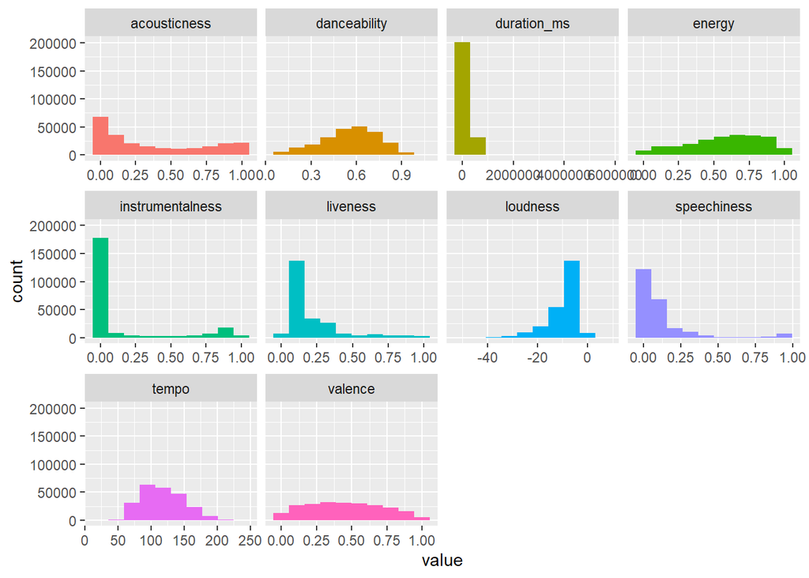

```r
spotify_hist <- tracks[,-c(1,2,3,4,5,11,17)]
plot_num(spotify_hist)
```

From the above it is interesting to note that danceability has a pretty normal distribution of songs in our dataset. To no surprise, there are not many people listening to Bach or YoYo Ma renditions of Vivaldi off late. We can clearly see the evidence of that by looking at the tall peak that signifies the clustering of most of our songs on the low to zero instrumental scale. Similarly, majority of the popular songs generally are 2- 5 mins long.

# Analysis and Visualizations

Now that we have pre-processed our data set, we can visualize basic data to find correlations among our variables.

From our data set, we can group our data set by genre and focus on the popularity parameter for visualization of data.

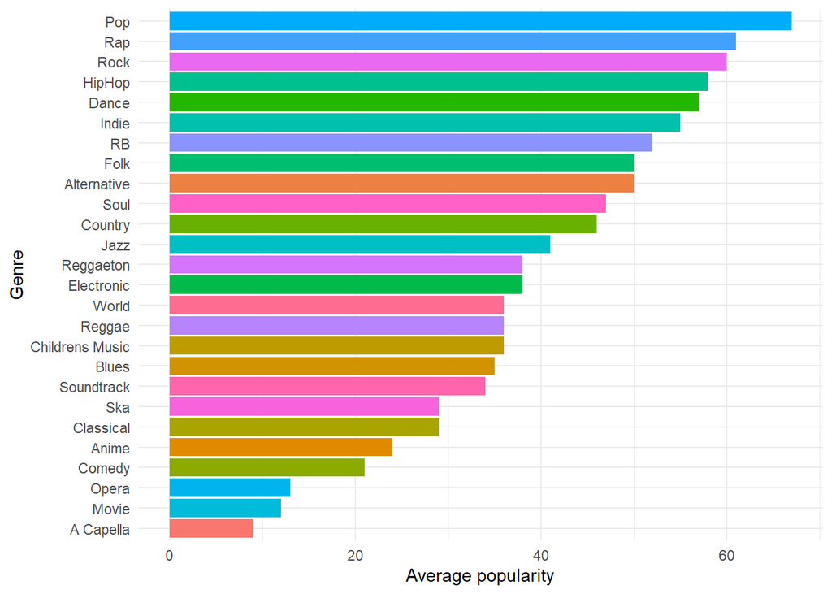

```r
genre_popularity <- tracks %>% select(popularity, genre) %>% group_by(genre) %>% summarise("average_popularity" = round(mean(popularity)))

p <- ggplot(data=genre_popularity, mapping = aes(x = reorder(genre,average_popularity), y = average_popularity, fill = genre)) +
  geom_col() +
  coord_flip() +
  theme_minimal() +
  theme(
    legend.position = "none",

  ) +
  labs(
    y = "Average popularity",
    x = "Genre"
  )

p
```

We have plotted the music genre from highest popularity to lowest popularity.

We can see that the Top 5 popular genres on spotify are - 1. Pop 2. Rap 3. Rock 4. HipHop 5. Dance

Genres with lowest popularity on spotify.

1. Anime
2. Comedy
3. Opera
4. Movie
5. A Capella

Let’s analyse the relationship between all numeric Spotify features now using a correlation map.

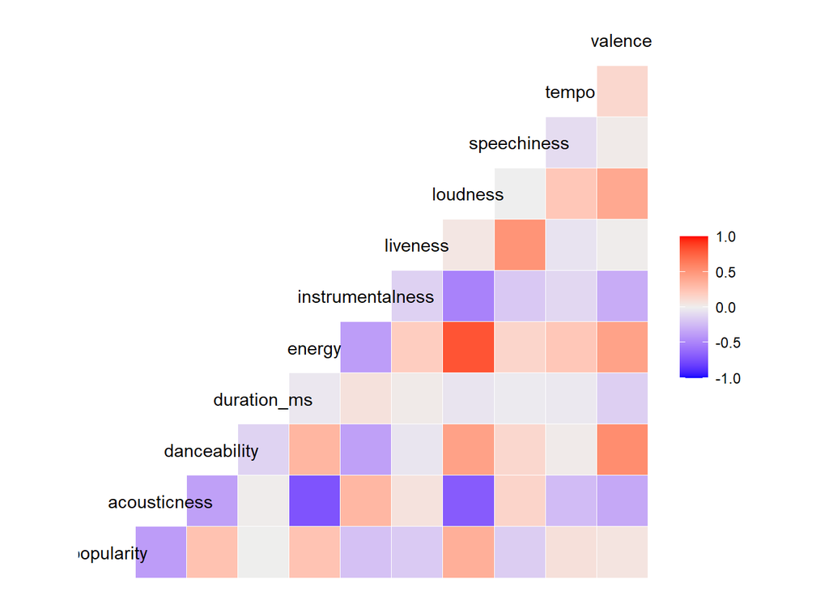

```r
# Plotting a correlation heat map to check correlation between all audio features.

ggcorr(tracks, low = "blue", high = "red")
```

From above graph we can list out below significant observations -

1. Energy and loudness have the highest correlation.
2. Energy and acousticness have a highly-correlated inverse relationship
3. Loudness and acousticness have a highly-correlated inverse relationship
4. Some of the variables most correlated to Popularity seem to be: acousticness, danceability, energy, instrumentalness, and loudness.